**Operator Learning**

By Prof. Seungchul Lee  
http://iailab.kaist.ac.kr/  
Industrial AI Lab at KAIST

Table of Contents

# 1. Lab 1: Euler Beam

## 1.1 Problem Setup

- We will solve a Euler beam problem using DeepONet:
- Only Data-driven
- Data and Physics-guided (BC)

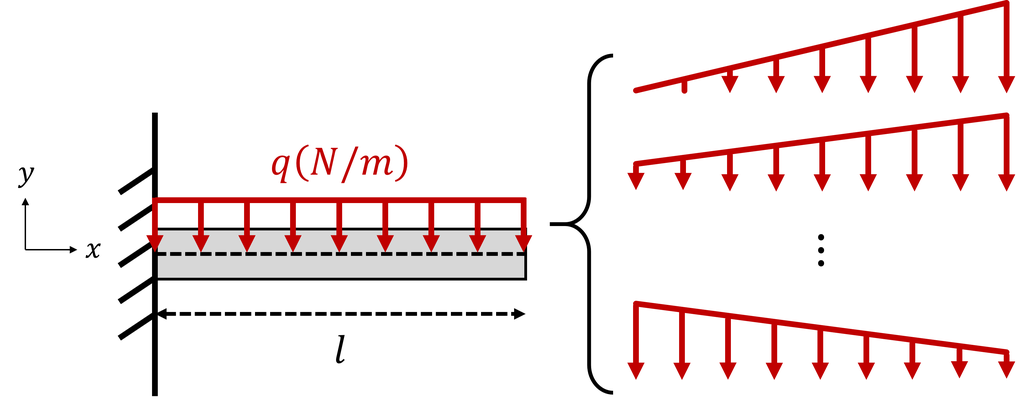

- Problem properties

$$E = 1 \operatorname{pa}, \quad I = 1 \operatorname{kg\cdot m^2}, \quad l = 1 \operatorname{m}, \quad q(x) = wx + w_0 \quad \text{where} \quad w_0 \in [0,2]$$

- The exact solution (Case of $w (x) = 1$) is

$$y(x) = -{1 \over 24}x^4 + {1 \over 6}x^3 - {1 \over 4}x^2$$

## 1.2. Solve the Euler Beam Problem with Data Driven DeepONet

- Make a neural network and loss functions like below :

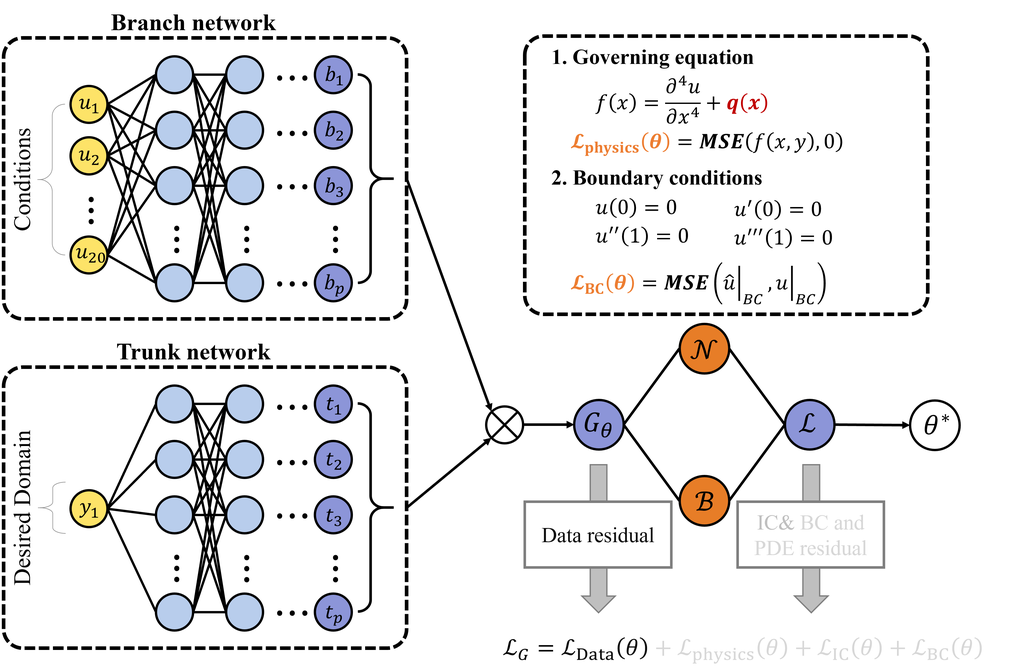

```python
from google.colab import drive
drive.mount('/content/drive')
```

### 1.2.1. Import Library

```python
import numpy as np
import matplotlib.pyplot as plt
import random
import os
import warnings
warnings.filterwarnings("ignore")

import torch
import torch.nn as nn
import torch.optim as optim
from torch.utils import data
%matplotlib inline
```

### 1.2.2. CUDA

```python
device = torch.device('cuda:0' if torch.cuda.is_available() else 'cpu')
print(device)
```

```
cuda:0
```

### 1.2.3. Random Seed

```python
def random_seed(seed = 2021):
    random.seed(seed)
    np.random.seed(seed)
    torch.manual_seed(seed)
    torch.cuda.manual_seed_all(seed)
    torch.backends.cudnn.deterministic = True
    torch.backends.cudnn.benchmark = False
```

### 1.2.4 Define Parameter

```python
# Properties
E = 1
I = 1
l = 1
```

### 1.2.5. Define Collocation Points

```python
'Domain collocation points'
domain_points = np.linspace(0, 1, 25).reshape(-1, 1)
```

#### Visualization

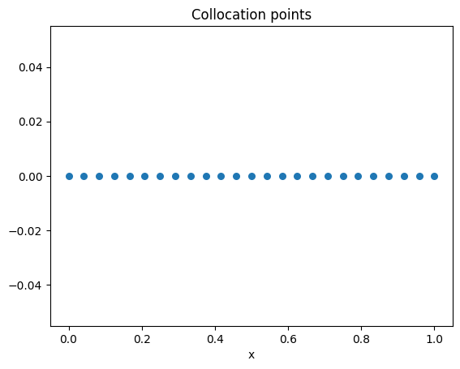

```python
'Plot'

y_init = np.zeros(25)

plt.scatter(domain_points, y_init, s = 30)
plt.xlabel('x')
plt.title('Collocation points')
plt.show()
```

### 1.2.6 Load $q(x)$ and Ground Truth

we use 10 distributed loads with varying $w_0$ and $w_1$ for training, and one distributed load for testing.

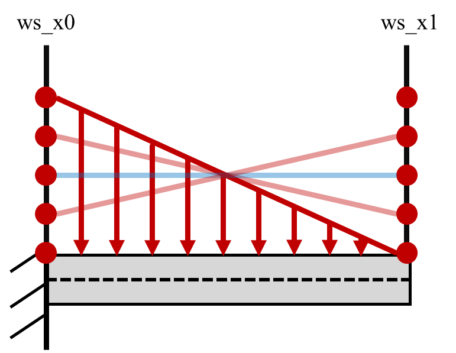

- [q_train](https://www.dropbox.com/scl/fi/6bq2ope23935puygq518l/q_train.npy?rlkey=c7gvuam1yz3wdo9430ttnb3nx&st=0fqvhkdt&dl=1)
- [q_test](https://www.dropbox.com/scl/fi/burfjwthsmqvql3mu6xkx/q_test.npy?rlkey=jfh5d7blhft9v0p1fh0z5v8e7&st=rgsocxt9&dl=1)
- [gt_train](https://www.dropbox.com/scl/fi/0v93ru0vcgb1tnglzcms5/gt_train.npy?rlkey=5d7cm8asb6knkpunm3dec31h5&st=0dzs2kzb&dl=1)
- [gt_test](https://www.dropbox.com/scl/fi/zzth8gda3jrusju27tj0i/gt_test.npy?rlkey=rb5andnz5gg2mnh4u9zniw7qb&st=yfk0mh22&dl=1)

```python
q_train = np.load('/content/drive/MyDrive/tutorials/기계인공지능연구회/본부학술대회_241106/DeepONet/data/beam_bending/q_train.npy')
q_test = np.load('/content/drive/MyDrive/tutorials/기계인공지능연구회/본부학술대회_241106/DeepONet/data/beam_bending/q_test.npy')
gt_train = np.load('/content/drive/MyDrive/tutorials/기계인공지능연구회/본부학술대회_241106/DeepONet/data/beam_bending/gt_train.npy')
gt_test = np.load('/content/drive/MyDrive/tutorials/기계인공지능연구회/본부학술대회_241106/DeepONet/data/beam_bending/gt_test.npy')

print('Loading Condtions for Train: {}'.format(q_train.shape))
print('Ground Truth for Train:      {}'.format(gt_train.shape))

print('Loading Condtions for Test:  {}'.format(q_test.shape))
print('Ground Truth for Test:       {}'.format(gt_test.shape))
```

```
Loading Condtions for Train: (10, 20)
Ground Truth for Train:      (10, 25)
Loading Condtions for Test:  (1, 20)
Ground Truth for Test:       (1, 25)
```

#### Visualize $P(x)$

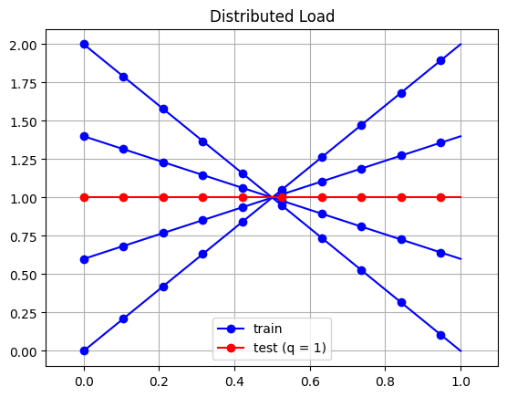

```python
# Plot Code
x_cor = np.linspace(0, 1, 20)

for i in range(10):
    if i == 0 or i == 3 or i == 6:
        a = q_train[i]
        plt.plot(x_cor, a, linestyle = '-', color = 'blue', marker= 'o', markevery = (0, 2))
    elif i == 9:
        a = q_train[i]
        plt.plot(x_cor, a, linestyle = '-', color = 'blue', marker='o', label = 'train', markevery = (0, 2))

plt.plot(x_cor, q_test.reshape(-1), linestyle = '-', color = 'red', marker = 'o', label = 'test (q = 1)', markevery = (0, 2))
plt.title("Distributed Load")
plt.legend()
plt.grid('on')
plt.xlim([-0.1, 1.1])
plt.ylim([-0.1, 2.1])
plt.show()
```

#### Visualize Ground Truth

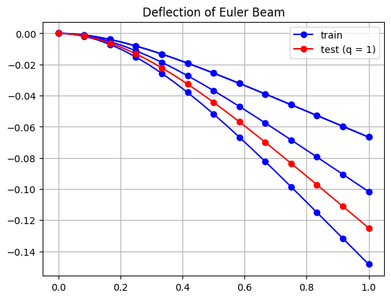

```python
# Plot Code
x_cor = np.linspace(0, 1, 25)

for i in range(10):
    if i == 0 or i == 3 or i == 6:
        a = gt_train[i]
        plt.plot(x_cor, a, linestyle = '-', color = 'blue', marker= 'o', markevery = (0, 2))
    elif i == 9:
        a = gt_train[i]
        plt.plot(x_cor, a, linestyle = '-', color = 'blue', marker='o', label = 'train', markevery = (0, 2))

plt.plot(x_cor, gt_test.reshape(-1), linestyle = '-', color = 'red', marker = 'o', label = 'test (q = 1)', markevery = (0, 2))
plt.title("Deflection of Euler Beam")
plt.legend()
plt.grid('on')
plt.show()
```

## 1.2.7. Generate Dataset

- Generate a dataset by stacking data for all conditions and collocation points like below:

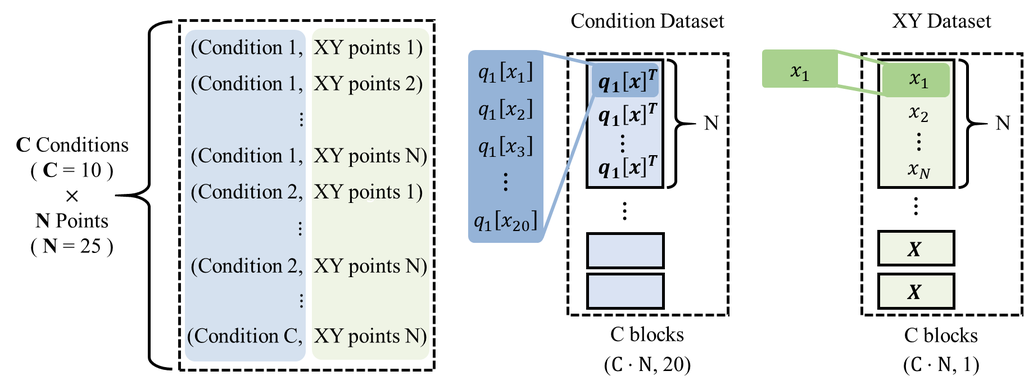

#### Domain

```python
# Load domain collocation points
num_domain = domain_points.shape[0]  # (25, _)
num_condition = q_train.shape[0]     # (10, _)

condition_list = []
XY_domain_list = []
gt_list = []

for i in range(num_condition):
    con = q_train[i]
    conditions = np.vstack([con] * num_domain)
    domains = domain_points
    gts = gt_train[i].reshape(-1, 1)

    condition_list.append(conditions)
    XY_domain_list.append(domains)
    gt_list.append(gts)

conditions_domain = np.vstack(condition_list)
XYs_domain = np.vstack(XY_domain_list)
gts_domain = np.vstack(gt_list)

print('Condtions Domain: {}'.format(conditions_domain.shape))
print('XYs Domain:       {}'.format(XYs_domain.shape))
print('GTs Domain:       {}'.format(gts_domain.shape))
```

```
Condtions Domain: (250, 20)
XYs Domain:       (250, 1)
GTs Domain:       (250, 1)
```

### 1.2.8. Data Generator

```python
# Data generator
class DataGenerator(data.Dataset):
    def __init__(self, c, XY, gt, batch_size=64, rng_seed=1234):
        'Initialization'
        self.c = torch.tensor(c, dtype = torch.float32)
        self.XY = torch.tensor(XY, dtype = torch.float32)
        self.gt = torch.tensor(gt, dtype = torch.float32)
        self.N = c.shape[0]
        self.batch_size = batch_size
        self.seed = rng_seed

    def __len__(self):
        return (self.N // self.batch_size) + 1

    def __getitem__(self, index):
        c, XY, gt = self.__data_generation(index)
        return c, XY, gt

    def __data_generation(self, index):
        torch.manual_seed(self.seed + index)

        idx = torch.randperm(self.N)[:self.batch_size]

        c = self.c[idx, :]
        XY = self.XY[idx, :]
        gt = self.gt[idx,:]

        return c, XY, gt
```

```python
batch_size = 30000
train_dataset = DataGenerator(conditions_domain, XYs_domain, gts_domain, batch_size)
```

### 1.2.9. Define Network and Hyper-parameter

```python
class MLP(nn.Module):
    def __init__(self, input_dim):
        super().__init__()

        self.linears = nn.Sequential(
            nn.Linear(input_dim, 32),
            nn.Tanh(),
            nn.Linear(32, 32),
            nn.Tanh(),
            nn.Linear(32, 32),
            nn.Tanh(),
            nn.Linear(32, 32),
            nn.Tanh(),
            nn.Linear(32, 16)
        )

    def forward(self, x):
        a = x.float()
        return self.linears(a)
```

```python
random_seed(seed = 2021)

dim_q = q_train[0].shape[0]

# Initialize model
branch_net = MLP(input_dim = dim_q).to(device)
trunk_net = MLP(input_dim = 1).to(device)

optimizer = optim.Adam(list(branch_net.parameters()) + list(trunk_net.parameters()), lr = 5e-4)
Loss_func = nn.MSELoss(reduction='mean')
```

### 1.2.10 Define Utility Function

```python
def DeepOnet(model, con_, X_):
    '''
    model = [branch_net, trunk_net]
    '''
    branch_net = model[0]
    trunk_net = model[1]

    B = branch_net(con_)
    T = trunk_net(X_)

    u = torch.sum(B * T, dim=1).unsqueeze(1)
    return u

def derivative(y, t) :
    df = torch.autograd.grad(y, t, create_graph = True, retain_graph = True, grad_outputs = torch.ones(y.size()).to(device))[0]
    return df

def requires_grad(x):
    return torch.tensor(x, requires_grad = True).to(device)
```

```python
'PLOT'

def PLOT(branch_test, trunk_test):
    branch_test.eval()
    trunk_test.eval()

    def exact_solution(x):
        return -(x ** 4) / 24 + x ** 3 / 6 - x ** 2 / 4

    test_q = q_test[0].reshape(1, 20)
    test_qs = np.vstack([test_q] * 25)
    test_XYs_domain = np.linspace(0, 1, 25).reshape(-1, 1)

    test_XYs_domain = requires_grad(test_XYs_domain)
    test_qs = requires_grad(test_qs)

    'DeepONet'
    B_test = branch_test(test_qs)
    T_test = trunk_test(test_XYs_domain)
    test_u = torch.sum(B_test * T_test, dim=1).unsqueeze(1)

    'Plot'
    x_ = np.linspace(0, l, len(test_u))
    plt.figure(figsize = (6, 4))
    plt.plot(x_, test_u.detach().cpu().numpy(), c =  'r', label = 'Predict u', linestyle = 'dashed', linewidth = 2)
    plt.plot(x_, exact_solution(x_), c =  'k', label = 'Exact Solution')
    plt.legend(fontsize = 10)
    plt.xticks(fontsize = 10)
    plt.yticks(fontsize = 10)
    plt.xlabel('Time (s)', fontsize = 10)
    plt.ylabel('Displacement (m)', fontsize = 10)
    plt.title('Test Result', fontsize = 15)
    plt.show()
#     clear_output(wait=True)
```

### 1.2.11. Train

```python
num_epochs = 2000
epoch = 0
```

```
Epoch: 0 Loss: 0.010332
```

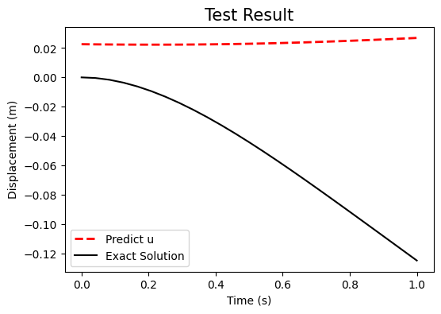

```
Epoch: 500 Loss: 0.000073
```

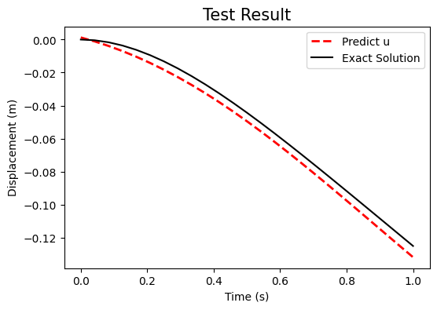

```
Epoch: 1000 Loss: 0.000017
```

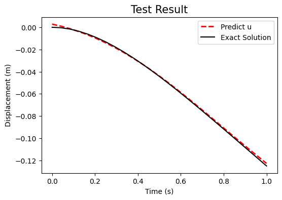

```
Epoch: 1500 Loss: 0.000006
```

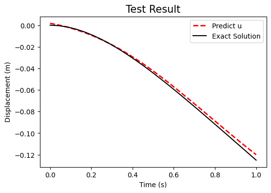

```
Epoch: 2000 Loss: 0.000005
```

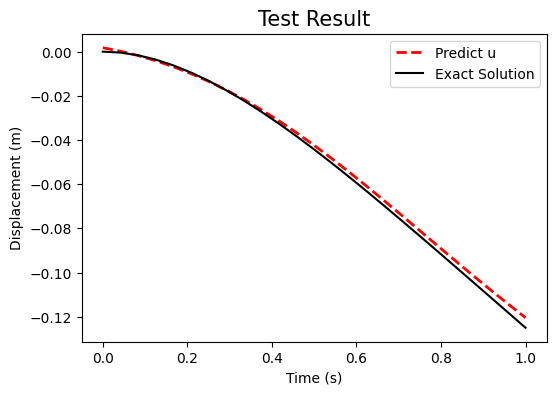

```python
train_iter = iter(train_dataset)

while epoch < num_epochs + 1:

    train_batch = next(train_iter)
    con_domain, XY_domain, gt_domain = train_batch

    ############### Reguires grad #################
    con_domain, XY_domain, gt_domain = requires_grad(con_domain), requires_grad(XY_domain), requires_grad(gt_domain)


    model = [branch_net, trunk_net]
    T_domain = DeepOnet(model, con_domain, XY_domain)


    ################# Data loss ###################
    loss_data = Loss_func(T_domain.float(), gt_domain.float().to(device))

    loss = loss_data

    optimizer.zero_grad()
    loss.backward()
    optimizer.step()

    # if epoch % 100 == 0:
    #     with torch.no_grad():
    #         print('Epoch: {} Loss: {:.6f} '.format(epoch, loss.item()))

    if epoch % 500 == 0:
        with torch.no_grad():
            print('Epoch: {} Loss: {:.6f} '.format(epoch, loss.item()))
            PLOT(branch_net, trunk_net)

    epoch += 1
```

## 1.3 Solve the Euler Beam Problem with Data and Physics-guide DeepONet

- Problem properties

$$E = 1 \operatorname{pa}, \quad I = 1 \operatorname{kg\cdot m^2}, \quad l = 1 \operatorname{m}, \quad q(x) = wx + w_0$$

$$\quad \text{where} \quad w \in [-2,2] \quad \text{and} \quad w_0 \in [0,2] $$

- One Dirichlet boundary condition on the left boundary:

$$y(0) = 0$$

- One Neumann boundary condition on the left boundary:

$$y'(0) = 0$$

- Two boundary conditions on the right boundary:

$$y''(1) = 0, \quad y'''(1) = 0$$

- The exact solution (Case of $w (x) = 1$) is

$$y(x) = -{1 \over 24}x^4 + {1 \over 6}x^3 - {1 \over 4}x^2$$

- Make a neural network and loss functions like below :

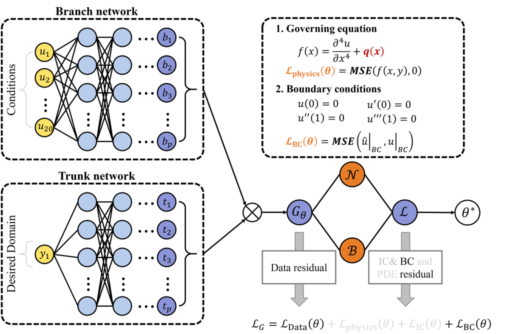

### 1.3.1. Define collocation Points

```python
'Domain collocation points'
domain_points = np.linspace(0, 1, 25).reshape(-1, 1)

'BC collocation points'
bc_points_x0 = (np.zeros(1)).reshape(-1, 1)
bc_points_x1 = (np.ones(1)).reshape(-1, 1)
```

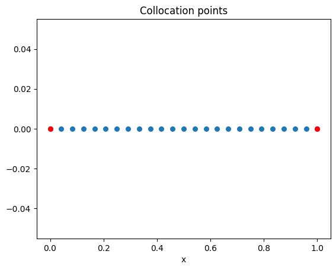

```python
'Plot'

y_init = np.zeros(25)

plt.scatter(domain_points, y_init, s = 30)
plt.scatter(bc_points_x0, 0, color = 'r', s = 30)
plt.scatter(bc_points_x1, 0, color = 'r', s = 30)
plt.xlabel('x')
plt.title('Collocation points')
plt.show()
```

### 1.3.2 Generate Dataset

#### Boundary Condition $x_0$

```python
num_BC = bc_points_x0.shape[0]     # (1, _)
num_condition = q_train.shape[0]   # (10, _)

condition_list = []
XY_bc0_list = []

for i in range(num_condition):
    con = q_train[i]
    conditions = np.vstack([con] * num_BC)
    bc_x0 = bc_points_x0

    condition_list.append(conditions)
    XY_bc0_list.append(bc_x0)

conditions_bc_x0 = np.vstack(condition_list)
XYs_bc_x0 = np.vstack(XY_bc0_list)

print('Conditions BC0: {}'.format(conditions_bc_x0.shape))
print('XYs BC0:        {}'.format(XYs_bc_x0.shape))
```

```
Conditions BC0: (10, 20)
XYs BC0:        (10, 1)
```

#### Boundary Condition $x_1$

```python
num_BC = bc_points_x1.shape[0]     # (1, _)
num_condition = q_train.shape[0]   # (10, _)

condition_list = []
XY_bc1_list = []

for i in range(num_condition):
    con = q_train[i]
    conditions = np.vstack([con] * num_BC)
    bc_x1 = bc_points_x1

    condition_list.append(conditions)
    XY_bc1_list.append(bc_x1)

conditions_bc_x1 = np.vstack(condition_list)
XYs_bc_x1 = np.vstack(XY_bc1_list)

print('Conditions BC1: {}'.format(conditions_bc_x1.shape))
print('Xs BC1:         {}'.format(XYs_bc_x1.shape))
```

```
Conditions BC1: (10, 20)
Xs BC1:         (10, 1)
```

### 1.3.3. Data Generator

```python
'BC generator'
class BCGenerator(data.Dataset):
    def __init__(self, c, XY, batch_size=64, rng_seed=1234):
        'Initialization'
        self.c = torch.tensor(c, dtype = torch.float32)
        self.XY = torch.tensor(XY, dtype = torch.float32)
        self.N = c.shape[0]
        self.batch_size = batch_size
        self.seed = rng_seed

    def __len__(self):
        return (self.N // self.batch_size) + 1

    def __getitem__(self, index):
        c, XY = self.__data_generation(index)
        return c, XY

    def __data_generation(self, index):
        torch.manual_seed(self.seed + index)

        idx = torch.randperm(self.N)[:self.batch_size]

        c = self.c[idx, :]
        XY = self.XY[idx, :]

        return c, XY
```

```python
batch_size = 30000
train_bc_x0_dataset = BCGenerator(conditions_bc_x0, XYs_bc_x0, batch_size)
train_bc_x1_dataset = BCGenerator(conditions_bc_x1, XYs_bc_x1, batch_size)
```

### 1.3.4. Define Networks and Hyper-parameter

```python
class MLP(nn.Module):
    def __init__(self, input_dim):
        super().__init__()

        self.linears = nn.Sequential(
            nn.Linear(input_dim, 32),
            nn.Tanh(),
            nn.Linear(32, 32),
            nn.Tanh(),
            nn.Linear(32, 32),
            nn.Tanh(),
            nn.Linear(32, 32),
            nn.Tanh(),
            nn.Linear(32, 16)
        )

    def forward(self, x):
        a = x.float()
        return self.linears(a)
```

```python
random_seed(seed = 5)

dim_q = q_train[0].shape[0]

# Initialize model
branch_net = MLP(input_dim = dim_q).to(device)
trunk_net = MLP(input_dim = 1).to(device)

optimizer = optim.Adam(list(branch_net.parameters()) + list(trunk_net.parameters()), lr = 5e-4)
Loss_func = nn.MSELoss(reduction='mean')
```

### 1.3.5. Define Usable Function

```python
def PIDeepOnet(model, con_, X_):
    '''
    model = [branch_net, trunk_net]
    '''
    branch_net = model[0]
    trunk_net = model[1]

    B = branch_net(con_)
    T = trunk_net(X_)

    u = torch.sum(B * T, dim=1).unsqueeze(1)
    return u

def derivative(y, t) :
    df = torch.autograd.grad(y, t, create_graph = True,retain_graph = True, grad_outputs = torch.ones(y.size()).to(device))[0]
    return df

def requires_grad(x):
    return torch.tensor(x, requires_grad = True).to(device)
```

```python
'PLOT'
def PLOT(branch_test, trunk_test):
    branch_test.eval()
    trunk_test.eval()

    def exact_solution(x):
        return -(x ** 4) / 24 + x ** 3 / 6 - x ** 2 / 4

    test_q = q_test[0].reshape(1, 20)
    test_qs = np.vstack([test_q] * 25)
    test_XYs_domain = np.linspace(0, 1, 25).reshape(-1, 1)

    test_XYs_domain = requires_grad(test_XYs_domain)
    test_qs = requires_grad(test_qs)

    'DeepONet'
    B_test = branch_test(test_qs)
    T_test = trunk_test(test_XYs_domain)
    test_u = torch.sum(B_test * T_test, dim=1).unsqueeze(1)

    'Plot'
    x_ = np.linspace(0, l, len(test_u))
    plt.figure(figsize = (6, 4))
    plt.plot(x_, test_u.detach().cpu().numpy(), c = 'r', label = 'Predict u', linestyle = 'dashed', linewidth = 2)
    plt.plot(x_, exact_solution(x_), c = 'k', label = 'Exact Solution')
    plt.legend(fontsize = 10)
    plt.xticks(fontsize = 10)
    plt.yticks(fontsize = 10)
    plt.xlabel('Time (s)', fontsize = 10)
    plt.ylabel('Displacement (m)', fontsize = 10)
    plt.title('Test Result', fontsize = 15)
    plt.show()
#     clear_output(wait=True)
```

### 1.3.6. Define Boundary Condition

- One Dirichlet boundary condition on the left boundary:

$$y(0) = 0$$

- One Neumann boundary condition on the left boundary:

$$y'(0) = 0$$

- Two boundary conditions on the right boundary:

$$y''(1) = 0, \quad y'''(1) = 0$$

```python
def BC_x0(model, c_x0, XY_x0):

    u_0 = PIDeepOnet(model, c_x0, XY_x0)
    u_x_0 = derivative(u_0, XY_x0)

    return u_0.float(), u_x_0.float()


def BC_x1(model, c_x1, XY_x1):

    u_1 = PIDeepOnet(model, c_x1, XY_x1)
    u_x_1 = derivative(u_1, XY_x1)
    u_xx_1 = derivative(u_x_1, XY_x1)
    u_xxx_1 = derivative(u_xx_1, XY_x1)

    return  u_xx_1.float(), u_xxx_1.float()
```

### 1.3.6. Train

```python
num_epochs = 2000

epoch = 0
```

```
Epoch: 0 Loss: 0.003302
```

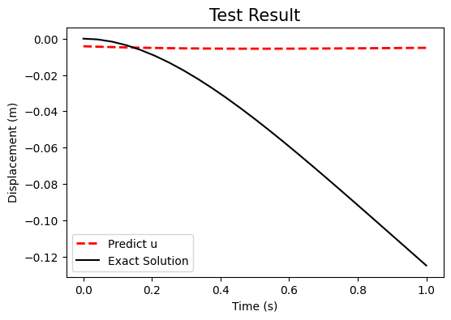

```
Epoch: 500 Loss: 0.000150
```

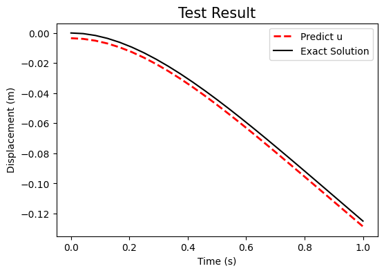

```
Epoch: 1000 Loss: 0.000065
```

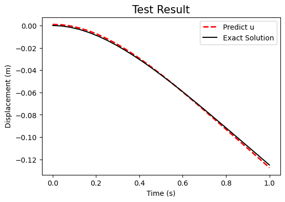

```
Epoch: 1500 Loss: 0.000007
```

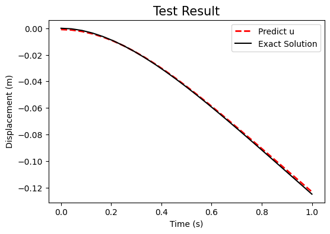

```
Epoch: 2000 Loss: 0.000001
```

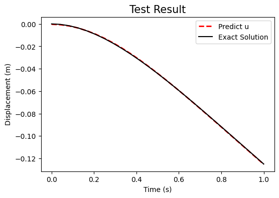

```python
train_iter = iter(train_dataset)
train_bc_x0_iter = iter(train_bc_x0_dataset)
train_bc_x1_iter = iter(train_bc_x1_dataset)

while epoch < num_epochs + 1:

    train_batch = next(train_iter)
    train_bc_x0_batch = next(train_bc_x0_iter)
    train_bc_x1_batch = next(train_bc_x1_iter)

    con_domain, XY_domain, gt_domain = train_batch
    con_x0, XY_x0 = train_bc_x0_batch
    con_x1, XY_x1 = train_bc_x1_batch

    ############### Reguires grad #################
    'Domain'
    con_domain, XY_domain, gt_domain = requires_grad(con_domain), requires_grad(XY_domain), requires_grad(gt_domain)
    'BC'
    con_x0, XY_x0 = requires_grad(con_x0), requires_grad(XY_x0)
    con_x1, XY_x1 = requires_grad(con_x1), requires_grad(XY_x1)


    model = [branch_net, trunk_net]
    T_domain = PIDeepOnet(model, con_domain, XY_domain)


    ################# Data Loss ####################
    loss_data = Loss_func(T_domain.float(), gt_domain.float().to(device))

    ################## BC Loss #####################
    u_x0, du_x0 = BC_x0(model, con_x0, XY_x0)
    ddu_x1, dddu_x1 = BC_x1(model, con_x1, XY_x1)

    loss_BC_x0_1 = Loss_func(u_x0, torch.zeros_like(u_x0).to(device))
    loss_BC_x0_2 = Loss_func(du_x0, torch.zeros_like(du_x0).to(device))
    loss_BC_x1_1 = Loss_func(ddu_x1, torch.zeros_like(ddu_x1).to(device))
    loss_BC_x1_2 = Loss_func(dddu_x1, torch.zeros_like(dddu_x1).to(device))
    loss_bc = loss_BC_x0_1 + loss_BC_x0_2 + loss_BC_x1_1 + loss_BC_x1_2

    loss = loss_data + loss_bc

    optimizer.zero_grad()
    loss.backward()
    optimizer.step()

    if epoch % 500 == 0:
        with torch.no_grad():
            print('Epoch: {} Loss: {:.6f} '.format(epoch, loss.item()))
            PLOT(branch_net, trunk_net)

    epoch += 1
```

# 2. Lab 2: Elastic Deformation for Thin Plate (PI-DeepONet)

## 2.1. Problem Setup

- We will solve thin plate equations to find displacement and stress distribution of thin plate using PI-DeepONet
- Only Physics-informed (PDE and BC)

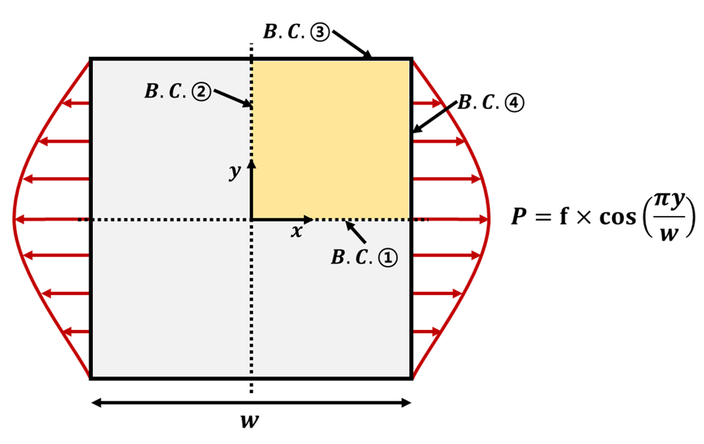

- Based on *Kirchhoff-Love* plate theory, three hypotheses were used
  - straight lines normal to the mid-surface remain straight after deformation
  - straight lines normal to the mid-surface remain normal to the mid-surface after deformation
  - the thickness of the plate does not change during a deformation
- A non-uniform stretching force is applied to square elastic plate
- Only one quarter of the plate is considered since the geometry and in-plane forces are symmetric (yellow domain)
- Problem properties

$$ E = 50 \operatorname{Mpa}, \quad \nu = 0.3, \quad \omega = 20 \operatorname{mm}, \quad h = 1 \operatorname{mm}, \quad f \operatorname{Mpa} \in [0.5, 1.5] $$

- Governing equations (Föppl–von Kármán equations) for the isotropic elastic plate:

$$ \begin{align*} &{E \over 1 - \nu^2}\left({\partial^2 u \over \partial x^2} + {1 - \nu \over 2}{\partial^2 u \over \partial y^2} + {1 + \nu \over 2}{\partial^2 v \over \partial x \partial y} \right) = 0\\\\ &{E \over 1 - \nu^2}\left({\partial^2 v \over \partial y^2} + {1 - \nu \over 2}{\partial^2 v \over \partial x^2} + {1 + \nu \over 2}{\partial^2 x \over \partial x \partial y} \right) = 0 \end{align*} $$

- Two Dirichlet boundary conditions at $x = 0,\, y = 0\; (B.C.①, B.C.②)$:

$$ v(x,y) = 0 \qquad \text{at} \quad y = 0\\\\ u(x,y) = 0 \qquad \text{at} \quad x = 0 $$

- Two free boundary conditions at $y = \omega / 2\; (B.C.③)$:

$$ \sigma_{yy} = 0,\quad \sigma_{yx} = 0 $$

- Free boundary condition and in-plane force boundary condition at $x = \omega / 2\; (B.C.④)$:

$$ \sigma_{xx} = P \centerdot h,\quad \sigma_{xy} = 0 $$

- Make a neural network and loss funcitons like below:

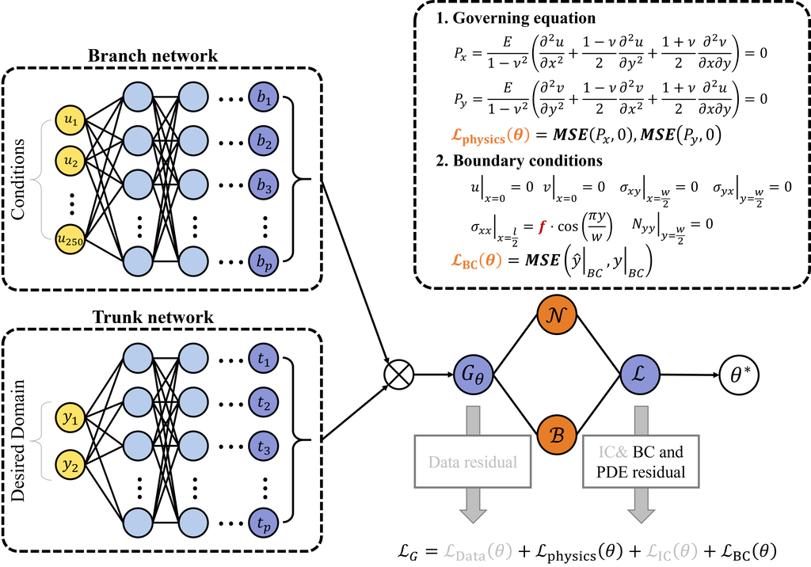

### 2.1.1 Numerical Solution

- Numerical solution of test case is one is illustrated in below figures:
- The case of $f$ = 1
- $x, y$ direction displacement and stress $u$, $v$, $\sigma_{xx}$, $\sigma_{yy}$, respectively
- Solve this problem using PI-DeepONet and then compare with a numerical solution

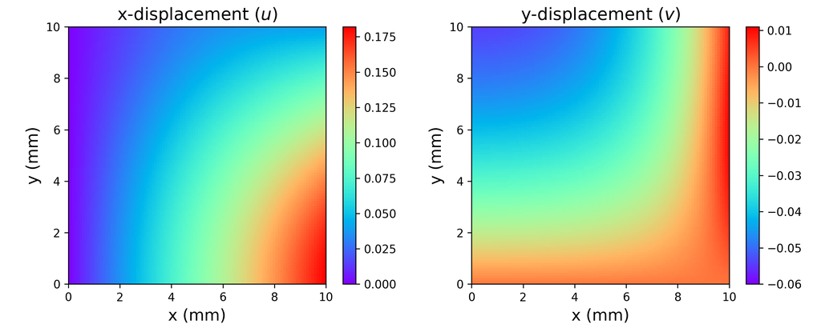

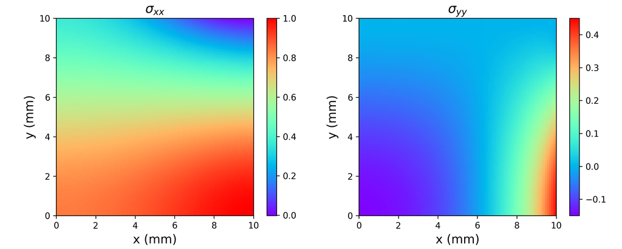

```python
from google.colab import drive
drive.mount('/content/drive')
```

## 2.2 Solve the Thin Plate Problem with PI-DeepONet

### 2.2.1 Load Library

```python
import numpy as np
import math
import matplotlib.pyplot as plt
import random
import os
import warnings
warnings.filterwarnings("ignore")

import torch
import torch.nn as nn
import torch.optim as optim
from torch.utils import data
%matplotlib inline
```

### 2.2.2. CUDA

```python
device = torch.device('cuda:0' if torch.cuda.is_available() else 'cpu')
print(device)
```

```
cuda:0
```

### 2.2.3. Random Seed

```python
def random_seed(seed = 5):
    random.seed(seed)
    np.random.seed(seed)
    torch.manual_seed(seed)
    torch.cuda.manual_seed_all(seed)
    torch.backends.cudnn.deterministic = True
    torch.backends.cudnn.benchmark = False
```

### 2.2.4. Define Properties

```python
# Properties
E = 50
nu = 0.3
a = 10
w = 10
h = 1
```

### 2.2.5. Generate Collocation Points

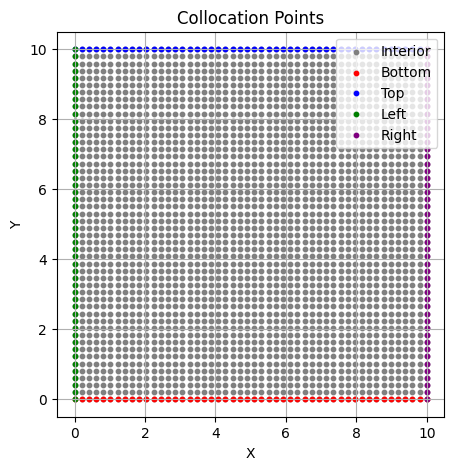

```python
Nx = 50                                           # Number of samples
Ny = 50                                           # Number of samples
x = np.linspace(0, w, Nx)                         # Input data for x (Nx x 1)
y = np.linspace(0, w, Ny)                         # Input data for y (Ny x 1)

xy = np.meshgrid(x, y)
xy_domain = np.concatenate((xy[0].reshape(-1, 1), xy[1].reshape(-1, 1)), 1)

xy_left = xy_domain[xy_domain[:, 0] == 0]
xy_right = xy_domain[xy_domain[: ,0] == w]
xy_top = xy_domain[xy_domain[:, 1] == w]
xy_bottom = xy_domain[xy_domain[:, 1] == 0]

plt.figure(figsize=(5, 5))
plt.scatter(xy_domain[:, 0], xy_domain[:, 1], s=10, color='gray', label='Interior')
plt.scatter(xy_bottom[:, 0], xy_bottom[:, 1], s=10, color='red', label='Bottom')
plt.scatter(xy_top[:, 0], xy_top[:, 1], s=10, color='blue', label='Top')
plt.scatter(xy_left[:, 0], xy_left[:, 1], s=10, color='green', label='Left')
plt.scatter(xy_right[:, 0], xy_right[:, 1], s=10, color='purple', label='Right')

plt.legend()
plt.title('Collocation Points')
plt.xlabel('X')
plt.ylabel('Y')
plt.grid(True)
plt.show()
```

### 2.2.6. Load $P(x)$

- [P_train](https://www.dropbox.com/scl/fi/8gea5tr68uq2nbzm2h2g5/tp_P_train.npy?rlkey=kwafejna4dg6x6inpznl3xn5m&st=g6dfj5dv&dl=1)
- [P_test](https://www.dropbox.com/scl/fi/jecnwy3pmkyddam31f9n2/tp_P_test.npy?rlkey=mqjlhqe6oeqxsbc0wjefbzgc3&st=irjizsu6&dl=1)

```python
# Define Condition parameter
full_f = [0.5, 0.6, 0.7, 0.8, 0.9, 1, 1.1, 1.2, 1.3, 1.4, 1.5]
f_train= [0.5, 0.6, 0.7, 0.8, 0.9, 1.1, 1.2, 1.3, 1.4, 1.5]
f_test = [1]

P_train = np.load('/content/drive/MyDrive/tutorials/기계인공지능연구회/본부학술대회_241106/DeepONet/data/thin_plate/tp_P_train.npy')
P_test = np.load('/content/drive/MyDrive/tutorials/기계인공지능연구회/본부학술대회_241106/DeepONet/data/thin_plate/tp_P_test.npy')

print('Loading Condtions for Train: {}'.format(P_train.shape))
print('Loading Condtions for Test:  {}'.format(P_test.shape))
```

```
Loading Condtions for Train: (10, 250)
Loading Condtions for Test:  (1, 250)
```

#### Plot

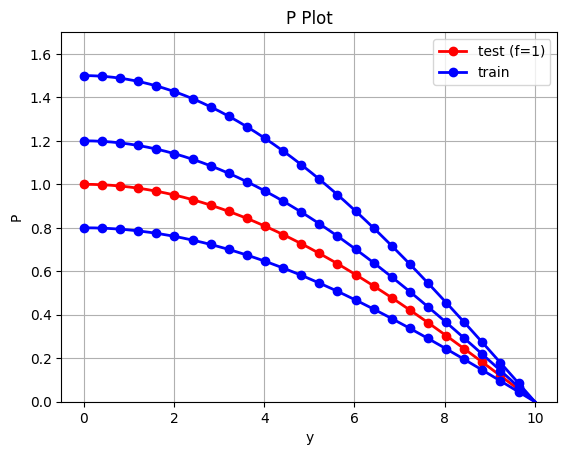

```python
x_cor = np.linspace(0, 10, 250)
plt.plot(x_cor, P_test[0], color = 'red', label = 'test (f=1)', linewidth = 2, marker= 'o', markevery = (0, 10))
plt.plot(x_cor, P_train[3], color = 'blue', label = 'train' ,linewidth = 2, marker= 'o', markevery = (0, 10))
plt.plot(x_cor, P_train[6], color = 'blue', linewidth = 2, marker= 'o', markevery = (0, 10))
plt.plot(x_cor, P_train[9], color = 'blue', linewidth = 2, marker= 'o', markevery = (0, 10))
plt.xlabel('y')
plt.ylabel('P')
plt.ylim([0,1.7])
plt.title('P Plot')
plt.grid('on')
plt.legend()
plt.show()
```

### 2.2.7. Generate Dataset

- Generate a dataset by stacking data for all conditions and collocation points like below:

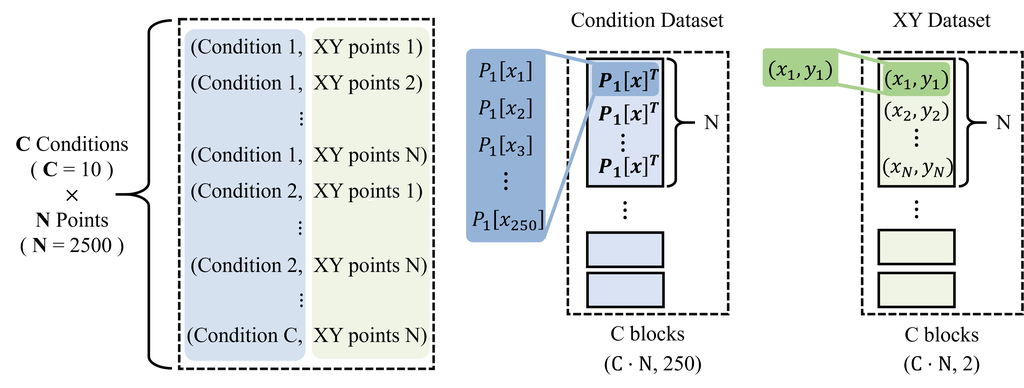

### Domain

```python
num_domain = xy_domain.shape[0]  # (2500,_)
num_condition = P_train.shape[0]  #(10,_)

condition_list = []
XY_domain_list = []

for i in range(num_condition):
    con = P_train[i]
    conditions = np.vstack([con] * num_domain)
    domains = xy_domain

    condition_list.append(conditions)
    XY_domain_list.append(domains)

conditions_domain = np.vstack(condition_list)
XYs_domain = np.vstack(XY_domain_list)

print('Condtions Domain: {}'.format(conditions_domain.shape))
print('XYs Domain:       {}'.format(XYs_domain.shape))
```

```
Condtions Domain: (25000, 250)
XYs Domain:       (25000, 2)
```

#### Boundary Condition $x_0$

```python
num_BC = xy_left.shape[0]    # (50,_)
num_condition = P_train.shape[0]  # (10,_)

condition_list = []
XY_left_list = []

for i in range(num_condition):
    con = P_train[i]
    conditions = np.vstack([con] * num_BC)
    XYs_bc_left = xy_left

    condition_list.append(conditions)
    XY_left_list.append(XYs_bc_left)

conditions_left = np.vstack(condition_list)
XYs_left = np.vstack(XY_left_list)

print('Conditions BC x0: {}'.format(conditions_left.shape))
print('XYs BC x0:        {}'.format(XYs_left.shape))
```

```
Conditions BC x0: (500, 250)
XYs BC x0:        (500, 2)
```

#### Boundary Condition $x_1$

```python
num_BC = xy_right.shape[0]    # (50,_)
num_condition = P_train.shape[0]  # (10,_)

condition_list = []
XY_right_list = []

for i in range(num_condition):
    con = P_train[i]
    conditions = np.vstack([con] * num_BC)
    XYs_bc_right = xy_right

    condition_list.append(conditions)
    XY_right_list.append(XYs_bc_right)

conditions_right = np.vstack(condition_list)
XYs_right = np.vstack(XY_right_list)

print('Conditions BC x1: {}'.format(conditions_right.shape))
print('XYs BC x1:        {}'.format(XYs_right.shape))
```

```
Conditions BC x1: (500, 250)
XYs BC x1:        (500, 2)
```

#### Boundary Condition $y_0$

```python
num_BC = xy_bottom.shape[0]    # (50,_)
num_condition = P_train.shape[0]  # (10,_)

condition_list = []
XY_bottom_list = []

for i in range(num_condition):
    con = P_train[i]
    conditions = np.vstack([con] * num_BC)
    XYs_bc_bottom = xy_bottom

    condition_list.append(conditions)
    XY_bottom_list.append(XYs_bc_bottom)

conditions_bottom = np.vstack(condition_list)
XYs_bottom = np.vstack(XY_bottom_list)

print('Conditions BC y0: {}'.format(conditions_bottom.shape))
print('XYs BC y0:        {}'.format(XYs_bottom.shape))
```

```
Conditions BC y0: (500, 250)
XYs BC y0:        (500, 2)
```